# Intratumoral T-cell and B-cell receptor architecture associates with distinct immune tumor microenvironment features and clinical outcomes of anti-PD-1/L1 immunotherapy

¶ TCGA data preparation ¶

Aimilia Schina

First created on 9 October 2019. Updated on 19 February 2024

```r
#####################
### Load packages ###
#####################
library(pacman)
pacman::p_load(DT, dplyr,readxl,TCGAbiolinks,splitstackshape,RTCGA,stringr,tibble,
               VennDiagram, randomcoloR, Amelia, mlbench, hrbrthemes, ggpubr, superheat, estimate,extrafont,TCGAbiolinks,ggvenn,
               data.table)
extrafont::loadfonts(device="win")
windowsFonts(sans="Palatino Linotype")
loadfonts(device="win")
loadfonts(device="postscript")
```

```r
###########################
### Main analysis paths ###
###########################
# Main
scriptsPath <- paste0("scripts/")
scriptsFunctionsPath <- paste0(scriptsPath,"functions/")
projectDataPath <- paste0("data/")
# Input
tcgaInputData <- paste0(projectDataPath,"TCGA/")
otherInputData <- paste0(projectDataPath,"other/")
referenceInputData <- paste0(projectDataPath,"reference/")
# Output
projectOutDataPath <- paste0("output/data_files/")
tcgaIntermediateData <- paste0(projectOutDataPath,"TCGA/")
# Session/dependencies
sessionInfoPath <- paste0("session_info/")

######################################
## Create intermediate output paths ##
######################################
if (!dir.exists(paste0(tcgaIntermediateData,"purity/"))) {dir.create(paste0(tcgaIntermediateData,"purity/"))}


##################################
### LOAD SOURCE FUNCTIONS FILE ###
##################################
source(paste0(scriptsFunctionsPath,"tcgaReplicateFilter.R"), local=T)
source(paste0(scriptsFunctionsPath,"tcga_clinical_biomarker_metadata_functions.R"), local=T)


#####################
### File suffixes ###
#####################
Rdata.suffix <- ".RData"


########################
### Script variables ###
########################
run_clean <- TRUE
```

# 1 Load data

Loading basic data objects and files for analysis.

## 1.1 Reference data

```r
geneid2symb <- read.table(file.path(paste0(referenceInputData, "genID2name.csv")), header = TRUE, sep = ",")
geneid2symb$gene_id <- as.character(geneid2symb$gene_id)
geneid2symb$gene_name <- as.character(geneid2symb$gene_name)
```

## 1.2 Gene expression signatures

TIS-GEP, TuTack, TLS (Johnsson paper) signatures.

```r
## Immune Gene signatures
gep_weights_df <- read.table(paste0(otherInputData,"Tcell_inflamed_gep_weights.txt"), header = TRUE, sep = "\t" )
normalization_genes_df <- read.table(paste0(otherInputData,"normalization_genes.txt"), header = TRUE, sep = "\t" )

# Load TuTack gene signature
TuTACK.DF <-loadRData(paste0(otherInputData,"TuTack_signature_weights",Rdata.suffix))
# Load tls signature
tls_df <- read.table(paste0(otherInputData,"tls_genes.txt"), header = TRUE, sep = "\t" )
```

## 1.3 Non filtered nonduplicated RNA TCGA sample data, including added molecular subtypes

```r
###############
## TCGA DATA ##
###############

### Load non filtered nonduplicated RNA TCGA sample data, including added molecular subtypes
biospecimen.tpnt.rna.merged.cl.f<-loadRData(paste0(tcgaIntermediateData,"biospecimen.merged.tpnt.RNA.noDup.sub.RData"))
# contains aliquot, analyte, patient, sample barcode
```

## 1.4 Other TCGA data from publications

```r
## TMB data
tmbDf <- read.table(paste0(tcgaInputData,"mutation-load_updated.txt"),sep="\t",header=T, stringsAsFactors=F,check.names=F)
colnames(tmbDf) <- gsub(" ", "_",colnames(tmbDf) )
colnames(tmbDf) <- gsub("-", "_",colnames(tmbDf) )
# contains patient, sample barcode


## ORR data
orrDf <- read_excel(paste0(otherInputData,"ORR_TMB_table.xlsx"),sheet = 2)
orrDf <- as.data.frame(orrDf[,c(1:4,9:10)])
colnames(orrDf) <- c("TCGA_ca", "PD1L1_responders","PD1L1_totalTreated", "ORR", "project","Additional_info")
# Select only lines with complete info in first 5 columns
orrDf_final <- orrDf[complete.cases(orrDf[,1:5]),]
# Change name for COAD MSI &MSS
orrDf_final$project[7:8] <- c("COAD_MSI", "COAD_MSS")
# only info for cohort

## MiTCR data
mitcrDf <- read.table(paste0(tcgaInputData, "samples_tcr_mitcr.txt"),sep="\t",header=T, stringsAsFactors=F,check.names=F)
mitcrDf$chain <- apply(mitcrDf[,c("V_segments","V_alleles","J_segments","J_alleles")],1, function(x) paste(x,collapse = " "))

mitcrDf$chain <- ifelse(grepl("TRA",mitcrDf$chain),"alpha",ifelse(grepl("TRB",mitcrDf$chain),"beta",ifelse(grepl("TRG",mitcrDf$chain),"gamma",ifelse(grepl("TRD",mitcrDf$chain),"delta",NA))))
# contains aliquot barcode


mitcrClonesDf <- plyr::count(mitcrDf, c("Sample_ID", "chain"))
colnames(mitcrClonesDf)[3] <- "NumClones"

## Try with ImmPancer new mitcr file found
# Load excel file
mitcrDf2 <- read_excel(paste0(tcgaInputData,"1-s2.0-S1074761318301213-mmc2.xlsx"),na = "NA")
colnames(mitcrDf2) <- gsub(" ","_",colnames(mitcrDf2))
colnames(mitcrDf2) <- gsub("\\...","_",colnames(mitcrDf2))
# contains patient barcode


## Participant metadata
participDf <- read.table(paste0(tcgaInputData,"participant.tsv"),sep="\t",header=T,stringsAsFactors=F,check.names=F)
participDf$sample_id2 <- sub('.*\\/', '', participDf$sample_id)
participDf$sample_id2 <- sub('\\..*', '', participDf$sample_id2)
# contains aliquot barcode


## Danaher immune infiltration data
### Danaher does not include results for UCEC!!!!-CHECK CIBERSORT
danaherImmInfDf <-read.table(paste0(tcgaInputData, "tcga_danaher.csv"),sep=",",header=T, stringsAsFactors=F,check.names=F)
colnames(danaherImmInfDf)[1] <- "Sample_ID"
danaherImmInfDf$Sample_ID <- gsub("\\.","-",danaherImmInfDf$Sample_ID)
# contains aliquot  barcode

## Cibersort data

## Clinical Survival data
# Load clinical data for tcga samples
#loading Clinical data https://gdc.cancer.gov/about-data/publications/PanCan-Clinical-2018
clinDf <- read.table(paste0(tcgaInputData,"TCGA-CDR-SupplementalTableS1_sheet.txt"),sep="\t",header=T, stringsAsFactors=F,check.names=F,comment.char="@")
# contains a patient barcode

## TCGA Tumor Purity - EVENTUALLY I CALCULATE MYSELF
tumorPurity <- read_excel(paste0(tcgaInputData,"41467_2015_BFncomms9971_MOESM1236_ESM.xlsx"),na = "NA",skip=3)
# dim(tumorPurity)
# unique(tumorPurity$`Cancer type`) %>% length()
tumorPurity <- tumorPurity[,1:3]
```

# 2 Estimate tumor purity

Run once since takes a lot of time. To run again, set run_clean to TRUE

```r
if(isTRUE(run_clean)){
  #####################################
  #####################################
  # Load per tissue and run ESTIMATE
  tcga_projects <-TCGAbiolinks:::getGDCprojects()$project_id
  mycancertypes.off <- tcga_projects[grepl("^TCGA-",tcga_projects)] # total 33

  res<- sapply(mycancertypes.off, function(x) calculateEstimateScore(paste0(tcgaInputData, "htseq_vst/"),"_RNASeqCountsVST.RData",paste0(tcgaIntermediateData,"purity/"),paste0(x),geneid2symb=geneid2symb))
  # # Just using the counts

  estimateDFs<- sapply(mycancertypes.off, function(x) readEstimateFiles(paste0(tcgaIntermediateData,"purity/"),x), simplify = FALSE)
  # estimateDFs.filt <- estimateDFs[-2]
  # Remove empty dataframes
  estimateDFs.filt <- Filter(function(x) !is.null(x), estimateDFs)
  # Merge into one dataframe
  estimateDFs.merged <- bind_rows(estimateDFs.filt)

  ## Select primary solid tumor codes
  estimateDFs.merged.tp <- subset(estimateDFs.merged,substr(estimateDFs.merged$run_accession,14,15) == "01")

  tumorPurityEstimate <- estimateDFs.merged.tp
  ## CALCULATE TUMOR PURITY
  tumorPurityEstimate$TumorPurity <- cos(0.6049872018+0.0001467884*tumorPurityEstimate$ESTIMATEScore)
  # Fix sample id
  tumorPurityEstimate$bcr_patient_barcode <- substr(tumorPurityEstimate$run_accession,1,12)
  tumorPurityEstimate$bcr_patient_barcode <- gsub(".", "-", tumorPurityEstimate$bcr_patient_barcode, fixed = TRUE)
  tumorPurityEstimate$run_accession <- gsub(".", "-", tumorPurityEstimate$run_accession, fixed = TRUE)

  # Save data
  save(tumorPurityEstimate, file=paste0(tcgaIntermediateData,"TCGA_estimateDF.notFiltered",Rdata.suffix))
}else{
  if(isTRUE(file.exists(paste0(tcgaIntermediateData,"TCGA_estimateDF.notFiltered",Rdata.suffix)))){
    tumorPurityEstimate <- loadRData(paste0(tcgaIntermediateData,"TCGA_estimateDF.notFiltered",Rdata.suffix))
  }else{
    print("There is no file with estimated tumor purity, set run_clean to True to calculate tumor purity for TCGA samples.")
  }
}
```

```
## [1] "Calculating stromal, immune and estimate scores for: TCGA-BRCA"
## [1] "Merged dataset includes 10041 genes (371 mismatched)."
## [1] "1 gene set: StromalSignature  overlap= 137"
## [1] "2 gene set: ImmuneSignature  overlap= 132"
## [1] "Calculating stromal, immune and estimate scores for: TCGA-STAD"
## [1] "Merged dataset includes 10041 genes (371 mismatched)."
## [1] "1 gene set: StromalSignature  overlap= 137"
## [1] "2 gene set: ImmuneSignature  overlap= 132"
## [1] "Calculating stromal, immune and estimate scores for: TCGA-LUAD"
## [1] "Merged dataset includes 10041 genes (371 mismatched)."
## [1] "1 gene set: StromalSignature  overlap= 137"
## [1] "2 gene set: ImmuneSignature  overlap= 132"
## [1] "Calculating stromal, immune and estimate scores for: TCGA-CHOL"
## [1] "Merged dataset includes 10041 genes (371 mismatched)."
## [1] "1 gene set: StromalSignature  overlap= 137"
```

[output cut: 149 more lines]

# 3 Filter data for non duplicated TCGA samples

Make sure all files including the TCGA cohorts are uniform, same names:

- COAD.MSS : COAD_MSS
- COAD.MSI_High: COAD_MSI
- COAD.MSI_Low: COAD_MSI_low
- BRCA.TripleNegative : BRCA_TN
- BRCA.Her2: BRCA_Her2
- BRCA.LuminalA : BRCA_LuminalA
- BRCA.LuminalB :BRCA_LuminalB
- BRCA.Normal: BRCA_Normal

```r
# ## In biοspecimen DF
biospecimen.tpnt.rna.merged.cl.f <-tcga_cohortTypesCorrection(biospecimen.tpnt.rna.merged.cl.f,"type")

## TMB data--NOT NEEDED
tmbDf <-tcga_cohortTypesCorrection(tmbDf,"Cohort")

## ORR data
orrDf_final<-tcga_cohortTypesCorrection(orrDf_final,"project")

## MiTCR data--NOT NEEDED
mitcrDf2 <-tcga_cohortTypesCorrection(mitcrDf2,"TCGA_Study")

## Participant metadata--NOT NEEDED
participDf <-tcga_cohortTypesCorrection(participDf,"disease")

## Danaher immune infiltration data--NOT NEEDED
### Danaher does not include results for UCEC!!!!-CHECK CIBERSORT
danaherImmInfDf <-tcga_cohortTypesCorrection(danaherImmInfDf,"tcga.dataset")

## Cibersort data

## Clinical Survival data--NOT NEEDED
clinDf <-tcga_cohortTypesCorrection(clinDf,"type")

# Tumor purity
tumorPurity <- tcga_cohortTypesCorrection(tumorPurity,"Cancer type")
```

We check the Tissue Source site Codes for the different data we have above, to see if they have common codes.

```r
biospTSS <- levels(as.factor(substr(biospecimen.tpnt.rna.merged.cl.f$bcr_patient_barcode,6,7)))
tmbTSS <-levels(as.factor(substr(tmbDf$Patient_ID,6,7)))
mitcrImmTSS <-levels(as.factor(substr(mitcrDf2$TCGA_Participant_Barcode,6,7)))
mitcrClonesTSS <-levels(as.factor(substr(mitcrClonesDf$Sample_ID,6,7)))
danaherTSS <-levels(as.factor(substr(danaherImmInfDf$Sample_ID,6,7)))
survTSS <-levels(as.factor(substr(clinDf$bcr_patient_barcode,6,7)))
participTSS <-levels(as.factor(substr(participDf$`entity:participant_id`,6,7)))
tumorPurityTSS <- levels(as.factor(substr(tumorPurityEstimate$run_accession,6,7)))
```

[figure not shown]

[figure not shown]

[figure not shown]

[figure not shown]

```r
# colors
set.seed(1234)
palette <- distinctColorPalette(2)

vinput4 <- list(#Biospecimen=biospTSS,
               #TMB=tmbTSS,
               MiTCRimm=mitcrImmTSS,
               MiTCRclones=mitcrClonesTSS
               # Danaher=danaherTSS,
               #Survival=survTSS
               )

vp <- invisible(venn.diagram(vinput4,
                   alpha = 0.6, filename = NULL,lty = "blank", fill = palette,
                   main= "",
                   main.cex = 1.1,
                   main.fontfamily="sans",
                   fontfamily ="sans",
                   sub.fontfamily = "sans",
                   cat.fontfamily = "sans",disable.logging = TRUE, output=FALSE

));
```

[output not shown]

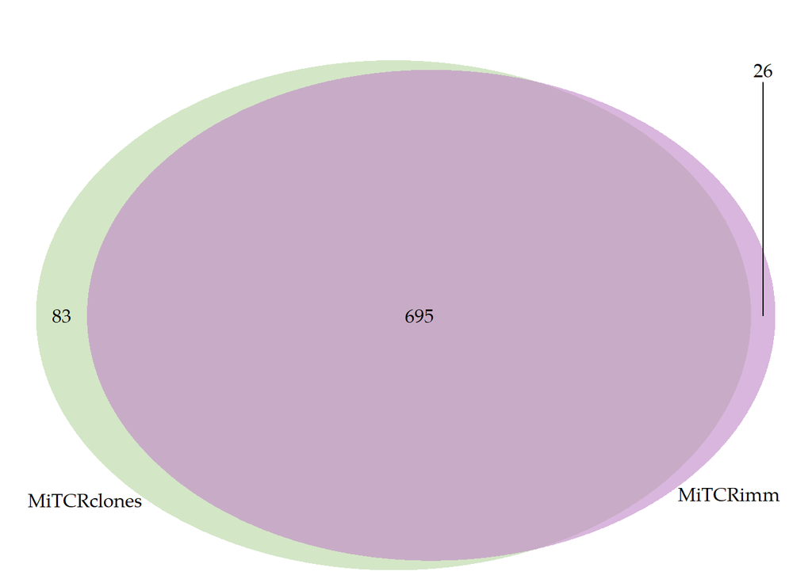

```r
grid.newpage()
grid.draw(vp)
```

Loading TCGA project names

```r
# TCGA projects
# Find TCGA projects
tcga_projects <-TCGAbiolinks:::getGDCprojects()$project_id
mycancertypes.tcgaBiolinks <- tcga_projects[grepl("^TCGA-",tcga_projects)] # total 33
mycancertypes.tcgaBiolinks.ord <- mycancertypes.tcgaBiolinks[order(mycancertypes.tcgaBiolinks)]
#list of tumor types from biospecimen data:
mycancertypes.tcgaBiolinks.ord.clean <- gsub("TCGA-","",mycancertypes.tcgaBiolinks.ord)

#####################
## SELECT PROJECTS ##
#####################
# ## Exclude THYM and DLBC
```

In addition we have added BRCA Triple Negative as a distinct subset of BRCA and we split COAD to COAD MSI (MSI high) and COAD MSS.

# 4 Load biospecimen, HTSEQ-VST normalized and RSEM TCGA data

Load TCGA sample data

```r
# Assign tumor samples and normal samples
tcga_TP <- biospecimen.tpnt.rna.merged.cl.f[biospecimen.tpnt.rna.merged.cl.f$sample_type=="TP",] #selecting tumors
tcga_NT <- biospecimen.tpnt.rna.merged.cl.f[biospecimen.tpnt.rna.merged.cl.f$sample_type=="NT",] #selecting normal tissue

#list of tumor types from biospecimen data:
mycancertypes.biosp.molSubtypes <- unique(tcga_TP$type)
mycancertypes.biosp.molSubtypes.ord <- mycancertypes.biosp.molSubtypes[order(mycancertypes.biosp.molSubtypes)]

#####################
## SELECT PROJECTS ##
#####################
# ## Exclude THYM and DLBC
# Setting the cancertypes for orr data as well
mycancertypes.orr <- mycancertypes.biosp.molSubtypes.ord

# Let's summarize the TCGA biospecimen data we just loaded
# Number of patients per project
biospecimen.tpnt.rna.merged.patient.sub.table <-biospecimen.tpnt.rna.merged.cl.f %>% select(type,bcr_patient_barcode) %>% group_by(type) %>% distinct() %>% summarize(n())
# Number of aliquots per project
biospecimen.tpnt.rna.merged.aliq.sub.table <- biospecimen.tpnt.rna.merged.cl.f %>% select(type,bcr_aliquot_barcode) %>% group_by(type) %>% distinct() %>% summarise(n())

# Table of number of replicates per patients per project
biospecimen.tpnt.rna.merged.aliqPatient.sub.table <-biospecimen.tpnt.rna.merged.cl.f %>% select(type,bcr_patient_barcode, bcr_aliquot_barcode) %>% group_by(type,bcr_patient_barcode) %>% distinct() %>% summarize(n())
```

**Summary Tables of TCGA biospecimen data**

```r
datatable(biospecimen.tpnt.rna.merged.patient.sub.table, extensions = 'Buttons', options = list(
    dom = 'Bfrtip',
    buttons = c('copy', 'excel', 'csv' ),
    scrollX=TRUE,
    pageLength=15
  ),
  caption = 'Number of patients per project (legacy & harmonized)'
)
```

|  | type | n() |
| --- | --- | --- |
| 1 | ACC | 80 |
| 2 | BLCA | 412 |
| 3 | BRCA | 1098 |
| 4 | BRCA_Her2 | 82 |
| 5 | BRCA_LuminalA | 568 |
| 6 | BRCA_LuminalB | 217 |
| 7 | BRCA_Normal | 140 |
| 8 | BRCA_TN | 191 |
| 9 | CESC | 307 |
| 10 | CHOL | 36 |

[output cut: 30 more lines]

```r
datatable(biospecimen.tpnt.rna.merged.aliq.sub.table, extensions = 'Buttons', options = list(
    dom = 'Bfrtip',
    buttons = c('copy', 'excel', 'csv' ),
    scrollX=TRUE,
    pageLength=15
  ),
  caption = 'Number of aliquots per project (legacy & harmonized)'
)
```

|  | type | n() |
| --- | --- | --- |
| 1 | ACC | 161 |
| 2 | BLCA | 893 |
| 3 | BRCA | 2485 |
| 4 | BRCA_Her2 | 185 |
| 5 | BRCA_LuminalA | 1297 |
| 6 | BRCA_LuminalB | 487 |
| 7 | BRCA_Normal | 494 |
| 8 | BRCA_TN | 433 |
| 9 | CESC | 633 |
| 10 | CHOL | 90 |

[output cut: 30 more lines]

```r
datatable(biospecimen.tpnt.rna.merged.aliqPatient.sub.table, extensions = 'Buttons', options = list(
    dom = 'Bfrtip',
    buttons = c('copy', 'excel', 'csv' ),
    scrollX=TRUE,
    pageLength=15
  ),
  caption = 'Number of replicate aliquots per patient per project (legacy & harmonized)'
)
```

|  | type | bcr_patient_barcode | n() |
| --- | --- | --- | --- |
| 1 | ACC | TCGA-OR-A5J1 | 2 |
| 2 | ACC | TCGA-OR-A5J2 | 2 |
| 3 | ACC | TCGA-OR-A5J3 | 2 |
| 4 | ACC | TCGA-OR-A5J4 | 3 |
| 5 | ACC | TCGA-OR-A5J5 | 2 |
| 6 | ACC | TCGA-OR-A5J6 | 2 |
| 7 | ACC | TCGA-OR-A5J7 | 2 |
| 8 | ACC | TCGA-OR-A5J8 | 2 |
| 9 | ACC | TCGA-OR-A5J9 | 2 |
| 10 | ACC | TCGA-OR-A5JA | 2 |

[output cut: 12200 more lines]

## 4.1 Calulcate TIS-GEP and TuTack signature scores

From the last table we can still see that there are several replicates for many patients. Eventually after merging with the expression data, we will filter the TCGA barcodes and end up with one aliquot per patient.

Load TCGA RNA HTSEQ-FPKM-UQ data for all cancers and calculate the signature scores for Expanded immune signature, IFNG (small, 6 genes), T cell-inflamed GEP (18 genes),the HTSEQ-VST data to calculate our “TuTACK” gene signature and the VST normalized PD-L1 expression.

Load the Level 3 RSEM-normalized RNASeqV2 data from TCGA

```r
# reading data
list.files( paste0(tcgaInputData, "rsem/")) %>%
  file.path( paste0(tcgaInputData, "rsem/"), .) -> folder

folder %>%
  list.files %>%
  file.path( folder, .) %>%
  grep( pattern = 'illuminahiseq', x = ., value = TRUE) -> pathRNA

dataNames<- gsub(paste0(paste0(tcgaInputData, "rsem//"),"gdac.broadinstitute.org_"),"",pathRNA)
# str_remove(pathRNA,paste0(paste0(tcgaIntermediateData, "rsem//"),"gdac.broadinstitute.org_"))

dataNames<- unlist(lapply(strsplit(dataNames,".Merge_rnaseqv2"), `[[`, 1))
names(pathRNA) <- dataNames
```

Get datasets for all TCGA and calculate TIS score

```
## [1] "ACC"
## [1] "BLCA"
## [1] "BRCA"
## [1] "CESC"
## [1] "CHOL"
## [1] "COAD"
## [1] "DLBC"
## [1] "ESCA"
## [1] "GBM"
## [1] "HNSC"
## [1] "KICH"
## [1] "KIRC"
## [1] "KIRP"
## [1] "LAML"
## [1] "LGG"
```

[output cut: 18 more lines]

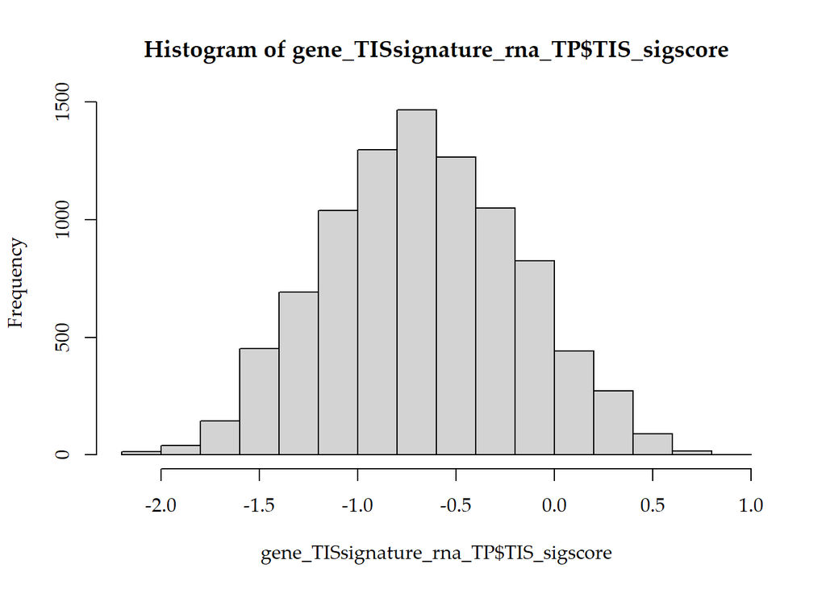

```
## [1] "Number of aliquots in RSEM Primary Tumor data"
## [1] "Number of unique patients in RSEM Primary Tumor data"
```

```
## [1] 9101
```

```r
if(isTRUE(run_clean)){
    gene_TISsignature_rna <- data.frame(Sample_ID=character(),
                                    tcga.dataset = character(),
                                    TIS_sigscore = numeric(),
                                    stringsAsFactors=FALSE)



  gene_TISsignature_rna <- sapply(mycancertypes.tcgaBiolinks.ord.clean,function(x) get_TIS_score_tcga_rsem(selectedcancer=x,gene_TISsignature_rna,gep_weights_df,normalization_genes_df),simplify = FALSE)


  # sapply(gene_TISsignature_rna, function(x) median(x[["TIS_sigscore"]]))
  # Merge data
  gene_TISsignature_rna  <-bind_rows(gene_TISsignature_rna , .id = "column_label")


  median(gene_TISsignature_rna$TIS_sigscore)

  # Save and don't run above each time
  save(gene_TISsignature_rna,file=paste0(tcgaIntermediateData,"gene_TISsignature_rna", Rdata.suffix))
  ##IMPORTANT!!: Select only primary solid tumor samples
  gene_TISsignature_rna_TP <- subset(gene_TISsignature_rna,substr(gene_TISsignature_rna$Sample_ID,14,15) == "01")
  # Histogram of TIS scores
  hist(gene_TISsignature_rna_TP$TIS_sigscore)
  ## CHECK
  print("Number of aliquots in RSEM Primary Tumor data")
  dim(gene_TISsignature_rna_TP)#9101
  # Number of  unique patients
  print("Number of unique patients in RSEM Primary Tumor data")
  length(unique(substr(gene_TISsignature_rna_TP$Sample_ID,1,12)))#9101

}else{
  if(isTRUE(file.exists(paste0(tcgaIntermediateData,"gene_TISsignature_rna", Rdata.suffix)))){
    gene_TISsignature_rna  <-loadRData(paste0(tcgaIntermediateData,"gene_TISsignature_rna", Rdata.suffix))
    ##IMPORTANT!!: Select only primary solid tumor samples
  gene_TISsignature_rna_TP <- subset(gene_TISsignature_rna,substr(gene_TISsignature_rna$Sample_ID,14,15) == "01")
  # Histogram of TIS scores
  hist(gene_TISsignature_rna_TP$TIS_sigscore)
  ## CHECK
  print("Number of aliquots in RSEM Primary Tumor data")
  dim(gene_TISsignature_rna_TP)#9101
  # Number of  unique patients
  print("Number of unique patients in RSEM Primary Tumor data")
  length(unique(substr(gene_TISsignature_rna_TP$Sample_ID,1,12)))#9101

  }else{
    print("There is no file with calculated TIS signatures, set run_clean to True to calculate TIS signature scores for TCGA samples.")
  }
}
```

# 5 MERGE ALL DATA

## 5.1 Filtering TCGA barcodes & fixing data columns

First rename column of aliquots so we can merge by one column, and transform data to have common columns with:

- project (BRCA, ACC)
- tcga.dataset (TCGA-BRCA, TCGA-ACC)
- bcr_aliquot_barcode#1:28
- bcr_analyte_barcode#1:20
- bcr_sample_barcode#1:16
- bcr_patient_barcode#1:12

We also need to add to all data apart from biospecimen the BRCA_Her2, BRCA_Luminal, BRCA_LuminalB,BRCA_Normal,BRCA_TN,COAD_MSI,COAD_MSI_low,COAD_MSS (so duplicate samples will exist)

For some patients we have multiple samples, multiple vials etc. Multiple samples can exist because there are samples from primary solid tumors, solid tissue normal etc..

For tumor we only consider:

- Primary solid Tumor - 01
- (Recurrent Solid Tumor) -02
- (Additional - New Primary) - 05
- (Metastatic) -06
- (Additional Metastatic) -07

## 5.2 Cibersort subsets aggregation for B cells, CD8 T cells, CD4 T cells.

```r
compactPopulations <- c("B_Cells_Naive","B_Cells_Memory","Plasma_Cells","T_Cells_CD8","T_Cells_CD4_Naive"           ,"T_Cells_CD4_Memory_Resting","T_Cells_CD4_Memory_Activated", "T_Cells_Regulatory_Tregs",
                        "NK_Cells_Resting","NK_Cells_Activated",
                        # "Dendritic_Cells_Resting","Dendritic_Cells_Activated",
                        # "Monocytes",
                        "Eosinophils_41","Mast_Cells_Resting","Mast_Cells_Activated","Neutrophils_48"
                        # "Macrophages_M0", "Macrophages_M1","Macrophages_M2"
                        )
# bcells <-c("B.Cells.Memory","B.Cells.Naive","Plasma.Cells")
# cd8 <-c("T.Cells.CD8.Naive","T.Cells.CD8.Actived","T.Cells.CD8.Memory")
# cd4 <-c("T.Cells.CD4.Naive","T.Cells.CD4.Memory")
# treg <-"Treg.Cells"
# nkcell <-c("NK.Resting", "NK.Actived")
# dc <-c("DC.Actived", "DC.Immature")
# mono <-"Monocyte"
# gran <-c("Eosinophil.Cells","Mast.Cells", "Neutrophil.Cells")
# macro<-c("M0.Macrophage", "M1.Macrophage","M2.Macrophage")

compactPopGroupsList <- list(B_cells=c("B_Cells_Naive","B_Cells_Memory","Plasma_Cells"),
                             CD8cells=c("T_Cells_CD8"),
                             CD4cells=c("T_Cells_CD4_Naive","T_Cells_CD4_Memory_Resting","T_Cells_CD4_Memory_Activated"),
                             Tregs = c("T_Cells_Regulatory_Tregs"),
                             NKcells=c("NK_Cells_Resting","NK_Cells_Activated"),
                             # DCcells=c("Dendritic_Cells_Resting","Dendritic_Cells_Activated"),
                             # Monocytes=c("Monocytes"),
                             Granulocytes=c("Eosinophils_41","Mast_Cells_Resting","Mast_Cells_Activated","Neutrophils_48")
                             # Macrophages=c("Macrophages_M0", "Macrophages_M1","Macrophages_M2")
                             )

compactNames<- names(compactPopGroupsList)



## ABSOLUTE

# Subset to compact sub-populations
resCiber_abs.c <- mitcrDf2.sub[,c(compactPopulations)] %>% as.data.frame()#"bcr_patient_barcode",
# resCiber_abs.c <- resCiber_abs.c %>% column_to_rownames(var="bcr_patient_barcode")

absCompact<- sapply(1:length(compactNames), function(x) sumColumns(resCiber_abs.c,compactNames[x],compactPopGroupsList[[x]]),simplify = FALSE)

absCompact <- bind_cols(absCompact)

mitcrDf2.sub <- cbind(mitcrDf2.sub, absCompact[-2])

colnames(mitcrDf2.sub)[31:64] <- paste0(colnames(mitcrDf2.sub)[31:64],".CIBER")



colnames(danaherImmInfDf.sub.f.agg)[4:17] <- str_remove(colnames(danaherImmInfDf.sub.f.agg)[4:17]," ")
colnames(danaherImmInfDf.sub.f.agg)[4:17] <-  paste0(colnames(danaherImmInfDf.sub.f.agg)[4:17],".DAN")
```

## 5.3 Merge

```r
# # Make dataframe with bcr patient barcode project and tcgha.dataset to deal with missing info on those.
# dfToMerge <- list(biospecimen.tpnt.rna.merged.cl.f.sub.f %>% as.data.frame(),
#                participDf.sub.f  %>% as.data.frame(),
#                clinDf.sub  %>% as.data.frame(),
#                tmbDf.sub  %>% as.data.frame(),
#                danaherImmInfDf.sub.f.agg  %>% as.data.frame(),
#                tumorPurityEstimate.sub.f.agg  %>% as.data.frame(),
#                 gene_signatures_rna.sub.f.agg  %>% as.data.frame(),
#                 gene_TISsignature_rna_TP.sub.f  %>% as.data.frame(),
#                 mitcrDf2.sub %>% as.data.frame())
#
# colsToMerge <- c(colnames(participDf.sub.f)[4:ncol(participDf.sub.f)],
#                  colnames(clinDf.sub)[4:ncol(clinDf.sub)],
#                  colnames(tmbDf.sub)[4:ncol(tmbDf.sub)],
#                  colnames(danaherImmInfDf.sub.f.agg)[4:ncol(danaherImmInfDf.sub.f.agg)],
#                  colnames(tumorPurityEstimate.sub.f.agg)[4:ncol(tumorPurityEstimate.sub.f.agg)],
#                  colnames(gene_signatures_rna.sub.f.agg)[4:ncol(gene_signatures_rna.sub.f.agg)],
#                  colnames(gene_TISsignature_rna_TP.sub.f)[4:ncol(gene_TISsignature_rna_TP.sub.f)],
#                  colnames(mitcrDf2.sub)[4:ncol(mitcrDf2.sub)]
#                  )
#
# tcga.tp.Filt.final <-rbindlist(dfToMerge, fill=TRUE)[, c("disease_name",
#                  "age_at_initial_pathologic_diagnosis", "gender","race",
#                  "ajcc_pathologic_tumor_stage","clinical_stage","histological_type",
#                  "histological_grade","initial_pathologic_dx_year", "menopause_status",
#                   "birth_days_to", "vital_status","tumor_status",
#                  "last_contact_days_to","death_days_to","cause_of_death",
#                 "new_tumor_event_type","new_tumor_event_site","new_tumor_event_site_other",
#                 "new_tumor_event_dx_days_to","treatment_outcome_first_course", "margin_status",
#                 "residual_tumor","OS", "OS.time",
#                 "DSS", "DSS.time","DFI",
#                 "DFI.time","PFI","PFI.time",
#                 "Redaction",
#                 "Silent_per_Mb","Non_silent_per_Mb", "logTMB","B-cells.DAN","DC.DAN","Macrophages.DAN","ExhaustedCD8.DAN","T-cells.DAN","CD8T cells.DAN","Neutrophils.DAN","Cytotoxiccells.DAN","Treg.DAN","NKCD56dim cells.DAN", "Mastcells.DAN","NKcells.DAN","CD45.DAN",            "Th1cells.DAN","StromalScore",  "ImmuneScore","ESTIMATEScore", "TumorPurity",
#                  "IFNg_expanded_sigscore", "IFNg_small_sigscore", "TuTACK_sigscore", "PD_L1",
#                  "TIS_sigscore",
#                  "TCGA_Subtype","Immune_Subtype","Leukocyte_Fraction",
#   "Stromal_Fraction","Intratumor_Heterogeneity","TIL_Regional_Fraction",
#   "Proliferation" , "Wound_Healing", "Macrophage_Regulation",
#   "Lymphocyte_Infiltration_Signature_Score", "IFN-gamma_Response", "TGF-beta_Response",
#   "SNV_Neoantigens","Indel_Neoantigens","Silent_Mutation_Rate",
#   "Nonsilent_Mutation_Rate","Number_of_Segments", "Fraction_Altered",
#   "Aneuploidy_Score","Homologous_Recombination_Defects","BCR_Evenness",
#   "BCR_Shannon", "BCR_Richness","TCR_Shannon",
#   "TCR_Richness","TCR_Evenness","CTA_Score",
#   "Th1_Cells.CIBER" ,"Th2_Cells.CIBER","Th17_Cells.CIBER",
#   "B_Cells_Memory.CIBER" ,"B_Cells_Naive.CIBER","Dendritic_Cells_Activated.CIBER",
#   "Dendritic_Cells_Resting.CIBER","Eosinophils_41.CIBER","Macrophages_M0.CIBER",
#   "Macrophages_M1.CIBER","Macrophages_M2.CIBER","Mast_Cells_Activated.CIBER",
#   "Mast_Cells_Resting.CIBER","Monocytes.CIBER","Neutrophils_48.CIBER",
#   "NK_Cells_Activated.CIBER","NK_Cells_Resting.CIBER","Plasma_Cells.CIBER",
#   "T_Cells_CD4_Memory_Activated.CIBER","T_Cells_CD4_Memory_Resting.CIBER","T_Cells_CD4_Naive.CIBER",
#   "T_Cells_CD8.CIBER","T_Cells_Follicular_Helper.CIBER" ,"T_Cells_gamma_delta.CIBER",
#   "T_Cells_Regulatory_Tregs.CIBER" ,"Lymphocytes.CIBER" ,"Mast_Cells.CIBER",
#   "Dendritic_Cells.CIBER","Macrophages.CIBER","B_cells.CIBER",
#   "CD4cells.CIBER" ,"Tregs.CIBER","NKcells.CIBER","Granulocytes.CIBER"
#                  ) :=lapply(.SD, na.omit) , bcr_patient_barcode, .SDcols=colsToMerge][] %>% distinct()
#

dfToMerge <- list(biospecimen.tpnt.rna.merged.cl.f.sub.f %>% as.data.frame(),
               participDf.sub.f  %>% as.data.frame(),
               clinDf.sub  %>% as.data.frame(),
               tmbDf.sub  %>% as.data.frame(),
               danaherImmInfDf.sub.f.agg  %>% as.data.frame(),
               tumorPurityEstimate.sub.f.agg  %>% as.data.frame(),
                gene_signatures_rna.sub.f.agg  %>% as.data.frame(),
                gene_TISsignature_rna_TP.sub.f  %>% as.data.frame(),
                mitcrDf2.sub %>% as.data.frame())

colsToMerge <- c(colnames(participDf.sub.f)[4:ncol(participDf.sub.f)],
                 colnames(clinDf.sub)[4:ncol(clinDf.sub)],
                 colnames(tmbDf.sub)[4:ncol(tmbDf.sub)],
                 colnames(danaherImmInfDf.sub.f.agg)[4:ncol(danaherImmInfDf.sub.f.agg)],
                 colnames(tumorPurityEstimate.sub.f.agg)[4:ncol(tumorPurityEstimate.sub.f.agg)],
                 colnames(gene_signatures_rna.sub.f.agg)[4:ncol(gene_signatures_rna.sub.f.agg)],
                 colnames(gene_TISsignature_rna_TP.sub.f)[4:ncol(gene_TISsignature_rna_TP.sub.f)],
                 colnames(mitcrDf2.sub)[4:ncol(mitcrDf2.sub)]
                 )

tcga.tp.Filt.final <-rbindlist(dfToMerge, fill=TRUE)[, c("disease_name",
                 "age_at_initial_pathologic_diagnosis", "gender","race",
                 "ajcc_pathologic_tumor_stage","clinical_stage","histological_type",
                 "histological_grade","initial_pathologic_dx_year", "menopause_status",
                  "birth_days_to", "vital_status","tumor_status",
                 "last_contact_days_to","death_days_to","cause_of_death",
                "new_tumor_event_type","new_tumor_event_site","new_tumor_event_site_other",
                "new_tumor_event_dx_days_to","treatment_outcome_first_course", "margin_status",
                "residual_tumor","OS", "OS.time",
                "DSS", "DSS.time","DFI",
                "DFI.time","PFI","PFI.time",
                "Redaction",
                "Silent_per_Mb","Non_silent_per_Mb", "logTMB","B-cells.DAN","DC.DAN","Macrophages.DAN","ExhaustedCD8.DAN","T-cells.DAN","CD8T cells.DAN","Neutrophils.DAN","Cytotoxiccells.DAN","Treg.DAN","NKCD56dim cells.DAN", "Mastcells.DAN","NKcells.DAN","CD45.DAN",            "Th1cells.DAN","StromalScore",  "ImmuneScore","ESTIMATEScore", "TumorPurity",
                 "IFNg_expanded_sigscore", "IFNg_small_sigscore", "TuTACK_sigscore", "PD_L1","TLS_score",
                 "TIS_sigscore",
                 "TCGA_Subtype","Immune_Subtype","Leukocyte_Fraction",
  "Stromal_Fraction","Intratumor_Heterogeneity","TIL_Regional_Fraction",
  "Proliferation" , "Wound_Healing", "Macrophage_Regulation",
  "Lymphocyte_Infiltration_Signature_Score", "IFN-gamma_Response", "TGF-beta_Response",
  "SNV_Neoantigens","Indel_Neoantigens","Silent_Mutation_Rate",
  "Nonsilent_Mutation_Rate","Number_of_Segments", "Fraction_Altered",
  "Aneuploidy_Score","Homologous_Recombination_Defects","BCR_Evenness",
  "BCR_Shannon", "BCR_Richness","TCR_Shannon",
  "TCR_Richness","TCR_Evenness","CTA_Score",
  "Th1_Cells.CIBER" ,"Th2_Cells.CIBER","Th17_Cells.CIBER",
  "B_Cells_Memory.CIBER" ,"B_Cells_Naive.CIBER","Dendritic_Cells_Activated.CIBER",
  "Dendritic_Cells_Resting.CIBER","Eosinophils_41.CIBER","Macrophages_M0.CIBER",
  "Macrophages_M1.CIBER","Macrophages_M2.CIBER","Mast_Cells_Activated.CIBER",
  "Mast_Cells_Resting.CIBER","Monocytes.CIBER","Neutrophils_48.CIBER",
  "NK_Cells_Activated.CIBER","NK_Cells_Resting.CIBER","Plasma_Cells.CIBER",
  "T_Cells_CD4_Memory_Activated.CIBER","T_Cells_CD4_Memory_Resting.CIBER","T_Cells_CD4_Naive.CIBER",
  "T_Cells_CD8.CIBER","T_Cells_Follicular_Helper.CIBER" ,"T_Cells_gamma_delta.CIBER",
  "T_Cells_Regulatory_Tregs.CIBER" ,"Lymphocytes.CIBER" ,"Mast_Cells.CIBER",
  "Dendritic_Cells.CIBER","Macrophages.CIBER","B_cells.CIBER",
  "CD4cells.CIBER" ,"Tregs.CIBER","NKcells.CIBER","Granulocytes.CIBER"
                 ) :=lapply(.SD, na.omit) , bcr_patient_barcode, .SDcols=colsToMerge][] %>% distinct()

table(tcga.tp.Filt.final$project)
```

```
##
##           ACC          BLCA          BRCA     BRCA_Her2 BRCA_LuminalA BRCA_LuminalB   BRCA_Normal       BRCA_TN          CESC          CHOL
##            92           412          1099            82           568           217           140           191           308            45
##          COAD      COAD_MSI  COAD_MSI_low      COAD_MSS          DLBC          ESCA           GBM          HNSC          KICH          KIRC
##           461            78            80           275            50           185           611           528           113           537
##          KIRP          LAML           LGG          LIHC          LUAD          LUSC          MESO            OV          PAAD          PCPG
##           291           200           516           377           583           504            87           606           185           179
##          PRAD          READ          SARC          SKCM          STAD          TGCT          THCA          THYM          UCEC           UCS
##           500           171           261           470           443           150           507           124           560            57
##           UVM
##            80
```

```r
median(tcga.tp.Filt.final$TIS_sigscore, na.rm = T)
```

```
## [1] -0.6764164
```

We want to keep the following data:

1. patient ID
2. TCGA project with molecular subtype
3. TCGA project (to see if for some missing)
4. TMB
5. GEP, TuTack scores & PD-L1 normalized expression
6. MiTCR clones
7. Immune pancancer data: Richness, Evenness, Shannon Entropy and infiltration data
8. Survival data

# 6 Missing values

Visualize variables and missing data across variables.

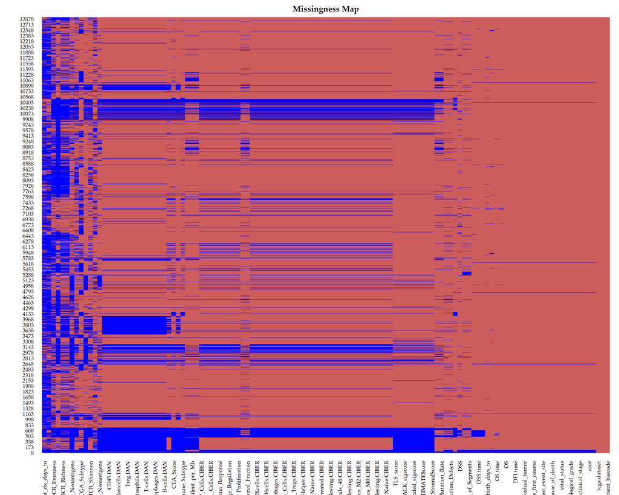

```r
visDF <- tcga.tp.Filt.final %>% distinct()

visDF <- visDF %>% distinct()

missmap(visDF, col=c("blue", "Indian red"), legend=FALSE)
```

# 7 Save data

```r
# save(tcga.tp.nonFilt.final,file=paste0(tcgaClinRDataPath, "tcga.tp.nonFilt.final.RData"))
save(tcga.tp.Filt.final,file=paste0(tcgaIntermediateData, "tcga.tp.Filt.final.RData"))
# save(tcga.tp.barcodes,file=paste0(tcgaClinRDataPath, "tcga.tp.barcodes.Filtered.RData"))
```

# 8 REMOVE ICI DATA

```r
mycancertypes <- levels(as.factor(tcga.tp.Filt.final$project))

## Exclude THYM and DLBC
mycancertypes.reduced <- mycancertypes[-which(mycancertypes %in% c("COAD_MSI_low","BRCA_Her2","BRCA_LuminalA", "BRCA_LuminalB","BRCA_Normal","BRCA_TN","COAD_MSI","COAD_MSS"))]

mycancertypes.multi <- mycancertypes.reduced[mycancertypes.reduced %in% c("SKCM","KIRC", "STAD", "BLCA")]

## Subset tables
tcga.tp.Filt.final.sub <- tcga.tp.Filt.final %>% dplyr::filter(project %in% mycancertypes.reduced)
```

## 8.2 FIND NON ICI SAMPLES

We want to exclude immunotherapies but not IFN-gamma, IFN-alpha, beta, IL-2

```r
# SKCM, STAD, BRCA_Her2 DLBC COAD_MSI
## Now subset tcga data to those patients that drug information
tcga.drug <-loadRData(paste0(tcgaIntermediateData,"tcga.drug",Rdata.suffix))
levels(tcga.drug$therapy_types)
```

```
##  [1] ""                                                     "Ancillary"
##  [3] "Chemotherapy"                                         "Hormone Therapy"
##  [5] "Immunotherapy"                                        "Other, specify in notesIsolated Limb Perfusion (ILP)"
##  [7] "Targeted Molecular therapy"                           "Vaccine"
##  [9] "Other, specify in notesAncillary"                     "Other, specify in notes"
## [11] "Other, specify in notesBiological Therapy"            "Other, specify in notesclinical trial"
## [13] "Other, specify in notesSU011248"                      "Other, specify in notesvaccine"
## [15] "Other, specify in notesVaccine"                       "Targeted Molecular therapySorafenib"
```

```r
unique(as.character(tcga.drug$drug_name))
```

```
##   [1] "Cyclophosphamide"                 ""                                 "Cisplatin"                        "Interferon"
##   [5] "Lupron"                           "GP-100"                           "recMAGE- A3"                      "Interferon alfa"
##   [9] "GP100"                            "MAGE-3"                           "Interferon-alfa"                  "Interferon Alpha"
##  [13] "MEL-44"                           "Interleukin-2"                    "Actinomycin-D"                    "Melphalan"
##  [17] "Resiquimod"                       "Vinblastine"                      "Dacarbazine"                      "Interferon alpha"
##  [21] "ipilimumab"                       "Pembrolizumab"                    "Ipilimumab"                       "Vemurafenib"
##  [25] "Laferon"                          "Carboplatin"                      "Temozolomide"                     "Temodal"
##  [29] "Alferon"                          "Fareston"                         "Lomustine"                        "Tamoxifen"
##  [33] "Zofran"                           "Dexamethasone"                    "Erythropoietin"                   "Ciclosporin"
##  [37] "RenAmin"                          "Leukine"                          "Bleomycin"                        "Vincristine"
##  [41] "PV-10"                            "Paclitaxel"                       "GSK Braf Inhibitor"               "Yervoy"
##  [45] "Dabrafenib"                       "Trametinib"                       "Fotemustine"                      "PNU-159548"
##  [49] "Cancer Vax"                       "MORAb-004"                        "VMCL"                             "autologous vaccine"
##  [53] "Dacabarzine"                      "BRAF inhibitor"                   "Mage A3"                          "PI88"
##  [57] "Alkeran"                          "interferon"                       "GM-CSF"                           "Patrin"
```

[output cut: 47 more lines]

```r
table(tcga.drug$project)
```

```
##
## TCGA-SKCM TCGA-STAD TCGA-KIRC TCGA-BLCA
##       274       475       181       427
```

```r
# DRUGS TO EXCLUDE
tcga.drug.ici <- tcga.drug %>% dplyr::filter(therapy_types %in% c("Immunotherapy")) %>% droplevels()
unique(as.character(tcga.drug.ici$drug_name))
```

```
##  [1] ""                               "Interferon"                     "Interferon alfa"                "Interferon-alfa"
##  [5] "Interferon Alpha"               "Interleukin-2"                  "Interferon alpha"               "ipilimumab"
##  [9] "Pembrolizumab"                  "Ipilimumab"                     "Laferon"                        "Alferon"
## [13] "Ciclosporin"                    "Leukine"                        "Yervoy"                         "MORAb-004"
## [17] "interferon"                     "IL-18"                          "IL-2"                           "Sylatron"
## [21] "interferon alpha"               "Interferon alfa-2b"             "Imiquimod"                      "Interleukin - 2"
## [25] "Interferon-a2"                  "IL2"                            "Diphencyprone"                  "pembrolizumab"
## [29] "Tyrosine kinase inhibitor"      "INF"                            "Oncophage"                      "Intron A"
## [33] "Proleukin"                      "Alpha Interferon"               "proleukin (IL-2)"               "interferon-alpha"
## [37] "oncophage vaccine"              "IFN-Alpha (Intron)"             "IL-2 (high dose)"               "Avastin"
## [41] "BCG"                            "Bacillus Calmette-Guerin (BCG)" "Nivolumab"                      "BCG, Intravesicular"
```

```r
ici_to_exclude <- c("ipilimumab" , "Pembrolizumab", "Ipilimumab")

tcga.drug.ici.To.Exclude <- tcga.drug %>% dplyr::filter(therapy_types %in% c("Immunotherapy")) %>%
                                          dplyr::filter(drug_name %in% ici_to_exclude) %>% droplevels() %>%
                                          pull(bcr_patient_barcode)

length(tcga.drug.ici.To.Exclude)
```

```
## [1] 24
```

```r
tcga.drug.ici.To.Exclude2 <- tcga.drug %>% dplyr::filter(drug_name %in% ici_to_exclude) %>% droplevels() %>%
                                          pull(bcr_patient_barcode)

length(tcga.drug.ici.To.Exclude2)
```

```
## [1] 27
```

```r
tcga.drug.ici.Only <- tcga.drug %>% dplyr::filter(bcr_patient_barcode %notin% tcga.drug.ici.To.Exclude2) %>% droplevels()

table(tcga.drug.ici.Only$project)
```

```
##
## TCGA-SKCM TCGA-STAD TCGA-KIRC TCGA-BLCA
##       226       475       181       423
```

## 8.3 Save data

```r
# save(tcga.drug.ici.Only,file=paste0(tcgaIntermediateData, "tcga.tp.Filt.final_ICI4Tissues.RData"))

save(tcga.drug.ici.To.Exclude2,file=paste0(tcgaIntermediateData, "tcga_patientsNOTici_toEXCLUDE_4Tissues.RData"))
```

# 9 Session

```r
# Cleanup
unlink(paste0("GDCdata"),recursive=TRUE)
unlink(paste0("MANIFEST.txt"),recursive=TRUE)
unlink(paste0('*VennDiagram*'))
# Session
writeLines(capture.output(session_info), paste0(sessionInfoPath,"A_06_tcga_clinical_biomarker_metadata.txt"))
```